# Reproducible Research: Peer Assessment 1

## Loading and preprocessing the data

It is now possible to collect a large amount of data about personal movement using activity monitoring devices such as a [Fitbit](http://www.fitbit.com/), [Nike Fuelband](http://www.nike.com/us/en_us/c/nikeplus-fuelband), or [Jawbone Up](https://jawbone.com/up). These type of devices are part of the “quantified self” movement - a group of enthusiasts who take measurements about themselves regularly to improve their health, to find patterns in their behavior, or because they are tech geeks. But these data remain under-utilized both because the raw data are hard to obtain and there is a lack of statistical methods and software for processing and interpreting the data.

This assignment makes use of data from a personal activity monitoring device that collects data at 5 minute intervals through out the day. The data was collected from an anonymous individual during the months of October and November 2012 and include the number of steps taken in 5 minute intervals each day.

```r
activity <- read.csv("activity.csv")
activity$date <- as.Date(activity$date, format="%Y-%m-%d")

library(plyr)
datesummary <- ddply(activity, .(date), summarise, total=sum(steps),
                     mean=mean(steps), median=median(steps))
```

## What is mean total number of steps taken per day?

The following histogram shows that for around half of the number of days in the duration, a total of between 10,000 and 15,000 steps were taken.

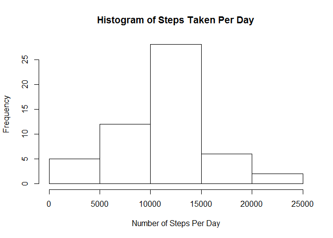

```r
hist(datesummary$total, breaks=7, xlab="Number of Steps Per Day",
     main="Histogram of Steps Taken Per Day")
```

```r
meansteps <- mean(datesummary$total, na.rm=TRUE)
mediansteps <- median(datesummary$total, na.rm=TRUE)
```

The mean and median of the number of steps per day are 1.0766 × 10<sup>4</sup> and 10765, respectively.

## What is the average daily activity pattern?

The following plot shows the mean number of steps per time interval.

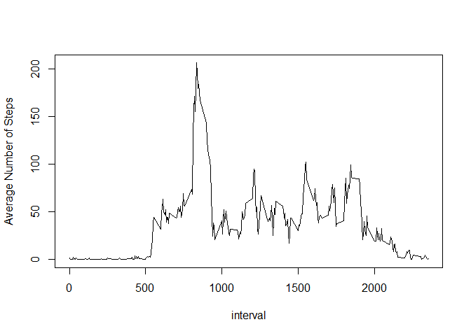

```r
timesummary <- ddply(activity, .(interval), summarise, total=sum(steps,na.rm=TRUE),
                     mean=mean(steps,na.rm=TRUE), median=median(steps,na.rm=TRUE))
with (timesummary, plot(interval, mean, type="l", ylab="Average Number of Steps"))
```

```r
maxindex <- which.max(timesummary$mean)
maxsteps <- timesummary$mean[maxindex]
maxinterval <- timesummary$interval[maxindex]
```

The maximum mean number of steps 206.17 is taken on the interval 835.

## Imputing missing values

```r
activity2 <- merge(activity, timesummary[,c("interval","mean")], by="interval", all=TRUE)
missing <- which(is.na(activity2$steps))
activity2$steps[missing] = activity2$mean[missing]
```

The dataset contains 2304 missing values. These could introduce bias into the calculations. In order to prevent this, the missing values will be replaced by the mean on all other days of the corresponding time interval. This results in the following histogram.

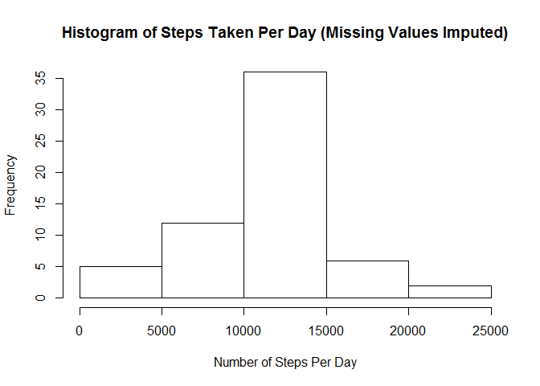

```r
datesummary2 <- ddply(activity2, .(date), summarise, total=sum(steps),
                     mean=mean(steps), median=median(steps))
hist(datesummary2$total, breaks=7, xlab="Number of Steps Per Day",
     main="Histogram of Steps Taken Per Day (Missing Values Imputed)")
```

Note that the shape of the histogram is basically the same as the original. Only the frequencies increased since values for missing days were filled in. The following chart shows the resulting total number of steps per day during the duration of the experiment.

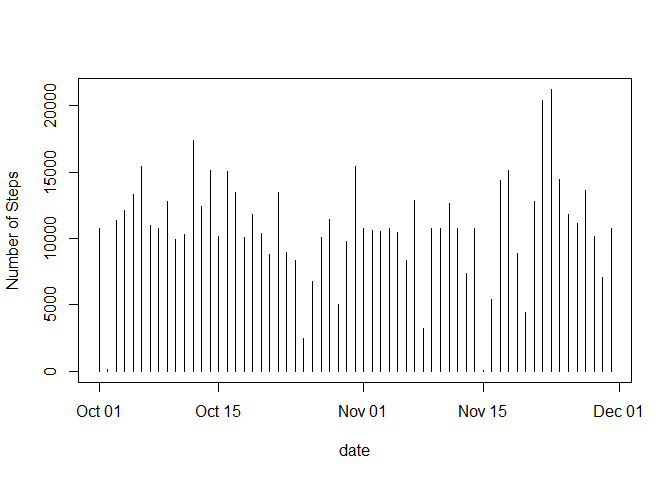

```r
with (datesummary2, plot(date, total, type="h", ylab="Number of Steps"))
```

```r
meansteps2 <- mean(datesummary2$total, na.rm=TRUE)
mediansteps2 <- median(datesummary2$total, na.rm=TRUE)
```

The updated mean and median of the number of steps per day are 1.0766 × 10<sup>4</sup> and 1.0766 × 10<sup>4</sup>, respectively. It can be noted that imputing missing values in this way has very little effect on the mean and median values of total number of steps taken per day.

## Are there differences in activity patterns between weekdays and weekends?

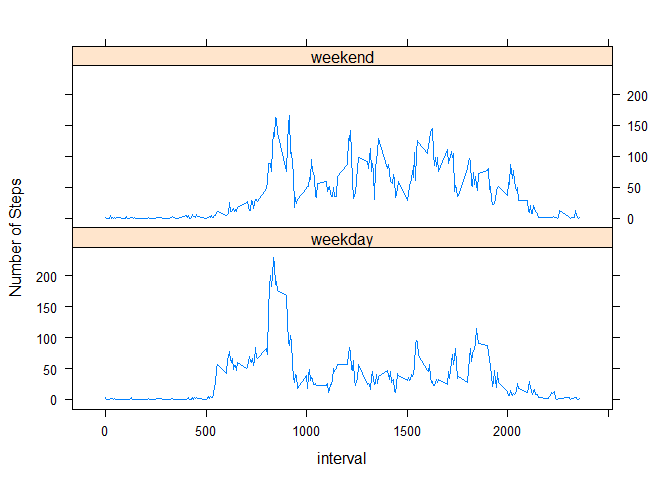

```r
activity2$day <- weekdays(activity2$date)
weekday <- data.frame(day=c("Monday","Tuesday","Wednesday","Thursday",
                             "Friday","Saturday","Sunday"),
                       dayindicator=c("weekday","weekday","weekday","weekday",
                                      "weekday","weekend","weekend"))
activity3 <- merge(activity2[,c("day","interval","steps")],weekday,by="day",all=TRUE)
daysummary <- ddply(activity3, .(interval, dayindicator), summarise,
                     mean=mean(steps))
library(lattice)
xyplot(mean ~ interval | dayindicator, data = daysummary, layout=c(1,2), type='l',
       ylab='Number of Steps')
```

It can be seen from comparing the two plots that on weekdays, there is considerably more activity between around 8am and 9am than the rest of the day on average. On weekends, the pace is more relaxed and there is more or less constant activity throughout the waking hours.